# Google Final Case Study Project Case Study: Fitness Tracking App - Calorie Related Analysis

Ahmed M. Abdo

2025-02-05

```r
knitr::opts_chunk$set(include = FALSE)
#Libraries Loading
if(!require(tidyverse)){install.packages("tidyverse")}
if(!require(gridExtra)){install.packages("gridExtra")}
```

```r
library(tidyverse)
library(readr)
library(dplyr)
library(ggplot2)
library(gridExtra)
```

# 1. Problem Definition

# 2. Data Collection

The data for this analysis comes from a publicly available Fitbit dataset. It includes various metrics related to daily activity, hourly activity, sleep, and weight. The following datasets were used:

- dailyActivity_merged.csv: Daily summary of activity.
- dailyCalories_merged.csv: Daily calorie estimates.
- dailyIntensities_merged.csv: Daily intensity levels.
- dailySteps_merged.csv: Daily step counts.
- hourlyCalories_merged.csv: Hourly calorie estimates.
- hourlyIntensities_merged.csv: Hourly intensity levels.
- hourlySteps_merged.csv: Hourly step counts.
- sleepDay_merged.csv: Daily sleep records.
- heartrate_seconds_merged.csv: Second-by-second heart rate data (not used in this analysis due to complexity).
- weightLogInfo_merged.csv: Weight logs.
- minuteCaloriesNarrow_merged.csv, minuteIntensitiesNarrow_merged.csv, minuteMETsNarrow_merged.csv, minuteStepsNarrow_merged.csv, minuteSleep_merged.csv:  
  Minute-level data (not used in this initial analysis due to aggregation requirements).

# 3. Data Cleaning and Preprocessing

### The Following Code Loads Data That we gonna work with Starting With the entire dataset.

```r
#Data loading in Variables
activity <- read.csv("dailyActivity_merged.csv")
calories <- read.csv("dailyCalories_merged.csv")
intensities <- read.csv("dailyIntensities_merged.csv")
steps <- read.csv("dailySteps_merged.csv")
hcalories <- read.csv("hourlyCalories_merged.csv")
hintensities <- read.csv("hourlyIntensities_merged.csv")
hsteps <- read.csv("hourlySteps_merged.csv")
dsleep <- read.csv("sleepDay_merged.csv")
heartrate <- read.csv("heartrate_seconds_merged.csv")
msleep <- read.csv("minuteSleep_merged.csv")
weight <- read.csv("weightLogInfo_merged.csv")
mcalories <- read_csv("minuteCaloriesNarrow_merged.csv")
mintensities <- read_csv("minuteIntensitiesNarrow_merged.csv")
mmets <- read_csv("minuteMETsNarrow_merged.csv")
msteps <- read_csv("minuteStepsNarrow_merged.csv")
```

###Checking Columns for Data Integrity and Check Our needs of the Data and understanding what each dataframe have to offer.

```r
#Checking Data Validation
colnames(activity)
```

```
##  [1] "Id"                       "ActivityDate"
##  [3] "TotalSteps"               "TotalDistance"
##  [5] "TrackerDistance"          "LoggedActivitiesDistance"
##  [7] "VeryActiveDistance"       "ModeratelyActiveDistance"
##  [9] "LightActiveDistance"      "SedentaryActiveDistance"
## [11] "VeryActiveMinutes"        "FairlyActiveMinutes"
## [13] "LightlyActiveMinutes"     "SedentaryMinutes"
## [15] "Calories"
```

```r
colnames(calories)
```

```
## [1] "Id"          "ActivityDay" "Calories"
```

```r
colnames(intensities)
```

```
##  [1] "Id"                       "ActivityDay"
##  [3] "SedentaryMinutes"         "LightlyActiveMinutes"
##  [5] "FairlyActiveMinutes"      "VeryActiveMinutes"
##  [7] "SedentaryActiveDistance"  "LightActiveDistance"
##  [9] "ModeratelyActiveDistance" "VeryActiveDistance"
```

```r
colnames(steps)
```

```
## [1] "Id"          "ActivityDay" "StepTotal"
```

```r
colnames(heartrate)
```

```
## [1] "Id"    "Time"  "Value"
```

```r
colnames(hcalories)
```

```
## [1] "Id"           "ActivityHour" "Calories"
```

```r
colnames(hintensities)
```

```
## [1] "Id"               "ActivityHour"     "TotalIntensity"   "AverageIntensity"
```

```r
colnames(hsteps)
```

```
## [1] "Id"           "ActivityHour" "StepTotal"
```

```r
colnames(mcalories)
```

```
## [1] "Id"             "ActivityMinute" "Calories"
```

```r
colnames(mintensities)
```

```
## [1] "Id"             "ActivityMinute" "Intensity"
```

```r
colnames(mmets)
```

```
## [1] "Id"             "ActivityMinute" "METs"
```

```r
colnames(msleep)
```

```
## [1] "Id"    "date"  "value" "logId"
```

```r
colnames(msteps)
```

```
## [1] "Id"             "ActivityMinute" "Steps"
```

```r
colnames(weight)
```

```
## [1] "Id"             "Date"           "WeightKg"       "WeightPounds"
## [5] "Fat"            "BMI"            "IsManualReport" "LogId"
```

```r
colnames(dsleep)
```

```
## [1] "Id"                 "SleepDay"           "TotalSleepRecords"
## [4] "TotalMinutesAsleep" "TotalTimeInBed"
```

```r
length(unique(activity$Id))
```

```
## [1] 33
```

```r
length(unique(heartrate$Id))
```

```
## [1] 14
```

```r
length(unique(hcalories$Id))
```

```
## [1] 33
```

```r
length(unique(hintensities$Id))
```

```
## [1] 33
```

```r
length(unique(hsteps$Id))
```

```
## [1] 33
```

```r
length(unique(mcalories$Id))
```

```
## [1] 33
```

```r
length(unique(mintensities$Id))
```

```
## [1] 33
```

```r
length(unique(mmets$Id))
```

```
## [1] 33
```

```r
length(unique(msleep$Id))
```

```
## [1] 24
```

```r
length(unique(msteps$Id))
```

```
## [1] 33
```

```r
length(unique(weight$Id))
```

```
## [1] 8
```

```r
length(unique(calories$Id))
```

```
## [1] 33
```

```r
length(unique(intensities$Id))
```

```
## [1] 33
```

```r
length(unique(steps$Id))
```

```
## [1] 33
```

```r
length(unique(dsleep$Id))
```

```
## [1] 24
```

### Finally Undstanding our Analysis Requirement and Begin to Work With

```r
# Choosing Which Tables to work With

head(activity)
```

```
##           Id ActivityDate TotalSteps TotalDistance TrackerDistance
## 1 1503960366    4/12/2016      13162          8.50            8.50
## 2 1503960366    4/13/2016      10735          6.97            6.97
## 3 1503960366    4/14/2016      10460          6.74            6.74
## 4 1503960366    4/15/2016       9762          6.28            6.28
## 5 1503960366    4/16/2016      12669          8.16            8.16
## 6 1503960366    4/17/2016       9705          6.48            6.48
##   LoggedActivitiesDistance VeryActiveDistance ModeratelyActiveDistance
## 1                        0               1.88                     0.55
## 2                        0               1.57                     0.69
## 3                        0               2.44                     0.40
## 4                        0               2.14                     1.26
## 5                        0               2.71                     0.41
## 6                        0               3.19                     0.78
##   LightActiveDistance SedentaryActiveDistance VeryActiveMinutes
## 1                6.06                       0                25
## 2                4.71                       0                21
## 3                3.91                       0                30
## 4                2.83                       0                29
## 5                5.04                       0                36
## 6                2.51                       0                38
##   FairlyActiveMinutes LightlyActiveMinutes SedentaryMinutes Calories
## 1                  13                  328              728     1985
## 2                  19                  217              776     1797
## 3                  11                  181             1218     1776
## 4                  34                  209              726     1745
## 5                  10                  221              773     1863
## 6                  20                  164              539     1728
```

```r
head(calories)
```

```
##           Id ActivityDay Calories
## 1 1503960366   4/12/2016     1985
## 2 1503960366   4/13/2016     1797
## 3 1503960366   4/14/2016     1776
## 4 1503960366   4/15/2016     1745
## 5 1503960366   4/16/2016     1863
## 6 1503960366   4/17/2016     1728
```

```r
head(dsleep)
```

```
##           Id              SleepDay TotalSleepRecords TotalMinutesAsleep
## 1 1503960366 4/12/2016 12:00:00 AM                 1                327
## 2 1503960366 4/13/2016 12:00:00 AM                 2                384
## 3 1503960366 4/15/2016 12:00:00 AM                 1                412
## 4 1503960366 4/16/2016 12:00:00 AM                 2                340
## 5 1503960366 4/17/2016 12:00:00 AM                 1                700
## 6 1503960366 4/19/2016 12:00:00 AM                 1                304
##   TotalTimeInBed
## 1            346
## 2            407
## 3            442
## 4            367
## 5            712
## 6            320
```

```r
head(steps)
```

```
##           Id ActivityDay StepTotal
## 1 1503960366   4/12/2016     13162
## 2 1503960366   4/13/2016     10735
## 3 1503960366   4/14/2016     10460
## 4 1503960366   4/15/2016      9762
## 5 1503960366   4/16/2016     12669
## 6 1503960366   4/17/2016      9705
```

```r
head(weight)
```

```
##           Id                  Date WeightKg WeightPounds Fat   BMI
## 1 1503960366  5/2/2016 11:59:59 PM     52.6     115.9631  22 22.65
## 2 1503960366  5/3/2016 11:59:59 PM     52.6     115.9631  NA 22.65
## 3 1927972279  4/13/2016 1:08:52 AM    133.5     294.3171  NA 47.54
## 4 2873212765 4/21/2016 11:59:59 PM     56.7     125.0021  NA 21.45
## 5 2873212765 5/12/2016 11:59:59 PM     57.3     126.3249  NA 21.69
## 6 4319703577 4/17/2016 11:59:59 PM     72.4     159.6147  25 27.45
##   IsManualReport        LogId
## 1           True 1.462234e+12
## 2           True 1.462320e+12
## 3          False 1.460510e+12
## 4           True 1.461283e+12
## 5           True 1.463098e+12
## 6           True 1.460938e+12
```

### Before starting we take a deep look at our summary statistics especially MAX MIN, to fully undstand and be able to avoid any errors while working with data.

```r
# Understanding Our tables for Better Decision and Understanding Statistical Rates

summary(activity)
```

```
##        Id            ActivityDate         TotalSteps    TotalDistance
##  Min.   :1.504e+09   Length:940         Min.   :    0   Min.   : 0.000
##  1st Qu.:2.320e+09   Class :character   1st Qu.: 3790   1st Qu.: 2.620
##  Median :4.445e+09   Mode  :character   Median : 7406   Median : 5.245
##  Mean   :4.855e+09                      Mean   : 7638   Mean   : 5.490
##  3rd Qu.:6.962e+09                      3rd Qu.:10727   3rd Qu.: 7.713
##  Max.   :8.878e+09                      Max.   :36019   Max.   :28.030
##  TrackerDistance  LoggedActivitiesDistance VeryActiveDistance
##  Min.   : 0.000   Min.   :0.0000           Min.   : 0.000
##  1st Qu.: 2.620   1st Qu.:0.0000           1st Qu.: 0.000
##  Median : 5.245   Median :0.0000           Median : 0.210
##  Mean   : 5.475   Mean   :0.1082           Mean   : 1.503
##  3rd Qu.: 7.710   3rd Qu.:0.0000           3rd Qu.: 2.053
##  Max.   :28.030   Max.   :4.9421           Max.   :21.920
##  ModeratelyActiveDistance LightActiveDistance SedentaryActiveDistance
##  Min.   :0.0000           Min.   : 0.000      Min.   :0.000000
##  1st Qu.:0.0000           1st Qu.: 1.945      1st Qu.:0.000000
##  Median :0.2400           Median : 3.365      Median :0.000000
##  Mean   :0.5675           Mean   : 3.341      Mean   :0.001606
##  3rd Qu.:0.8000           3rd Qu.: 4.782      3rd Qu.:0.000000
##  Max.   :6.4800           Max.   :10.710      Max.   :0.110000
##  VeryActiveMinutes FairlyActiveMinutes LightlyActiveMinutes SedentaryMinutes
##  Min.   :  0.00    Min.   :  0.00      Min.   :  0.0        Min.   :   0.0
##  1st Qu.:  0.00    1st Qu.:  0.00      1st Qu.:127.0        1st Qu.: 729.8
##  Median :  4.00    Median :  6.00      Median :199.0        Median :1057.5
##  Mean   : 21.16    Mean   : 13.56      Mean   :192.8        Mean   : 991.2
##  3rd Qu.: 32.00    3rd Qu.: 19.00      3rd Qu.:264.0        3rd Qu.:1229.5
##  Max.   :210.00    Max.   :143.00      Max.   :518.0        Max.   :1440.0
##     Calories
##  Min.   :   0
##  1st Qu.:1828
##  Median :2134
##  Mean   :2304
##  3rd Qu.:2793
##  Max.   :4900
```

```r
summary(calories)
```

```
##        Id            ActivityDay           Calories
##  Min.   :1.504e+09   Length:940         Min.   :   0
##  1st Qu.:2.320e+09   Class :character   1st Qu.:1828
##  Median :4.445e+09   Mode  :character   Median :2134
##  Mean   :4.855e+09                      Mean   :2304
##  3rd Qu.:6.962e+09                      3rd Qu.:2793
##  Max.   :8.878e+09                      Max.   :4900
```

```r
summary(dsleep)
```

```
##        Id              SleepDay         TotalSleepRecords TotalMinutesAsleep
##  Min.   :1.504e+09   Length:413         Min.   :1.000     Min.   : 58.0
##  1st Qu.:3.977e+09   Class :character   1st Qu.:1.000     1st Qu.:361.0
##  Median :4.703e+09   Mode  :character   Median :1.000     Median :433.0
##  Mean   :5.001e+09                      Mean   :1.119     Mean   :419.5
##  3rd Qu.:6.962e+09                      3rd Qu.:1.000     3rd Qu.:490.0
##  Max.   :8.792e+09                      Max.   :3.000     Max.   :796.0
##  TotalTimeInBed
##  Min.   : 61.0
##  1st Qu.:403.0
##  Median :463.0
##  Mean   :458.6
##  3rd Qu.:526.0
##  Max.   :961.0
```

```r
summary(steps)
```

```
##        Id            ActivityDay          StepTotal
##  Min.   :1.504e+09   Length:940         Min.   :    0
##  1st Qu.:2.320e+09   Class :character   1st Qu.: 3790
##  Median :4.445e+09   Mode  :character   Median : 7406
##  Mean   :4.855e+09                      Mean   : 7638
##  3rd Qu.:6.962e+09                      3rd Qu.:10727
##  Max.   :8.878e+09                      Max.   :36019
```

```r
summary(weight)
```

```
##        Id                Date              WeightKg       WeightPounds
##  Min.   :1.504e+09   Length:67          Min.   : 52.60   Min.   :116.0
##  1st Qu.:6.962e+09   Class :character   1st Qu.: 61.40   1st Qu.:135.4
##  Median :6.962e+09   Mode  :character   Median : 62.50   Median :137.8
##  Mean   :7.009e+09                      Mean   : 72.04   Mean   :158.8
##  3rd Qu.:8.878e+09                      3rd Qu.: 85.05   3rd Qu.:187.5
##  Max.   :8.878e+09                      Max.   :133.50   Max.   :294.3
##
##       Fat             BMI        IsManualReport         LogId
##  Min.   :22.00   Min.   :21.45   Length:67          Min.   :1.460e+12
##  1st Qu.:22.75   1st Qu.:23.96   Class :character   1st Qu.:1.461e+12
##  Median :23.50   Median :24.39   Mode  :character   Median :1.462e+12
##  Mean   :23.50   Mean   :25.19                      Mean   :1.462e+12
##  3rd Qu.:24.25   3rd Qu.:25.56                      3rd Qu.:1.462e+12
##  Max.   :25.00   Max.   :47.54                      Max.   :1.463e+12
##  NA's   :65
```

# 4. Exploratory Data Analysis (EDA)

### First we notice that date in most tables are considered strings for further data integrity, we need to convert it first for appropiate use.

```r
# Preparing to merge and work with final Data

activity <- activity %>%
  rename(date = ActivityDate) %>%
  mutate(date = as.Date(date, format = "%m/%d/%y"))
calories <- calories %>%
  rename(date = ActivityDay) %>%
  mutate(date = as.Date(date, format = "%m/%d/%y"))
dsleep <- dsleep %>%
  rename(date = SleepDay) %>%
  mutate(date = as.Date(date, format = "%m/%d/%y"))
steps <- steps %>%
  rename( date= ActivityDay) %>%
  mutate(date = as.Date(date, format = "%m/%d/%y"))
weight <- weight %>%
  rename(date = Date) %>%
  mutate(date = as.Date(date, format = "%m/%d/%y"))
hcalories <- hcalories %>%
  rename(date = ActivityHour) %>%
  mutate(date = as.Date(date, format = "%m/%d/%y"))
```

### Finally After Checking all data and preprocessing some data key elements, we begin to create our final table to start working with.

```r
#Memory allocation would be failure to join without Adjusting date

finaltable <- activity %>%
  left_join(hcalories, by = c("Id","date")) %>%
  left_join(calories, by = c("Id","date")) %>%
  left_join(steps, by = c("Id","date")) %>%
  left_join(weight, by = c("Id","date")) %>%
  left_join(dsleep, by = c("Id","date"), relationship = "many-to-many")
```

```r
#Final Clean Form to Work With



#Exporting Data Set for Clean work with Visualization
write_csv(finaltable, "FinalWorkingTable.csv")  # row.names = FALSE
```

# 5. Visualizations

### First we plot the relation between distance and burning calories to show when exactly burning calories efficiency taking place, and understanding how important is to monitor distance.

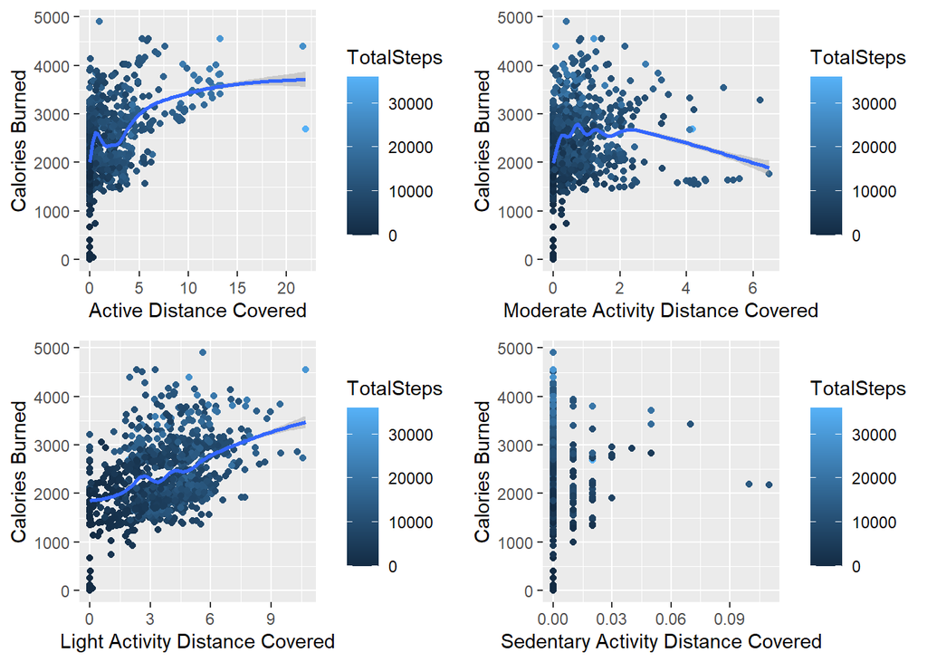

```r
#Visualization Relationship

#Undstanding Distance to Burning Calories

T1 <-  ggplot(finaltable, aes(x=VeryActiveDistance, y=Calories)) + geom_point(aes(color=TotalSteps)) + geom_smooth() + labs(x="Active Distance Covered", y="Calories Burned")
T2 <-  ggplot(finaltable, aes(x=ModeratelyActiveDistance, y=Calories)) + geom_point(aes(color=TotalSteps)) + geom_smooth() + labs(x="Moderate Activity Distance Covered", y="Calories Burned")
T3 <-  ggplot(finaltable, aes(x=LightActiveDistance, y=Calories)) + geom_point(aes(color=TotalSteps)) + geom_smooth() + labs(x="Light Activity Distance Covered", y="Calories Burned")
T4 <-  ggplot(finaltable, aes(x=SedentaryActiveDistance, y=Calories)) + geom_point(aes(color=TotalSteps)) + geom_smooth() + labs(x="Sedentary Activity Distance Covered", y="Calories Burned")

grid.arrange(T1,T2,T3,T4)
```

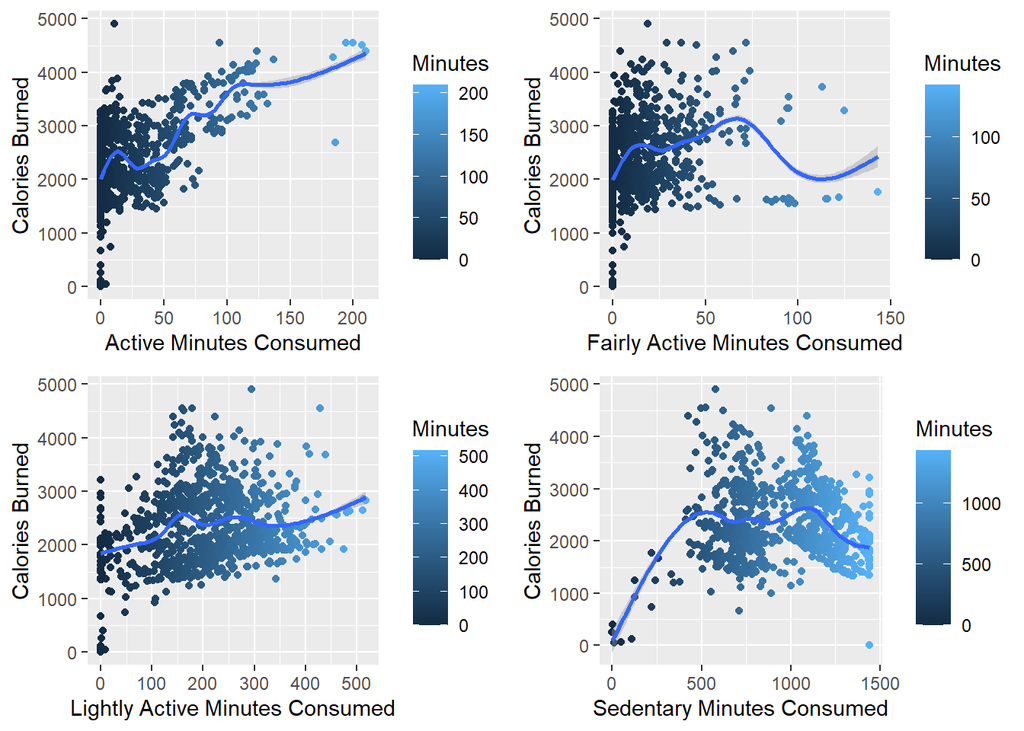

```r
#Understanding Time used for Burning Calories


M1 <- ggplot(finaltable, aes(x=VeryActiveMinutes, y=Calories)) + geom_point(aes(color=VeryActiveMinutes)) + geom_smooth() + labs(x="Active Minutes Consumed", y="Calories Burned",color="Minutes")
M2 <- ggplot(finaltable, aes(x=FairlyActiveMinutes, y=Calories)) + geom_point(aes(color=FairlyActiveMinutes)) + geom_smooth() + labs(x="Fairly Active Minutes Consumed", y="Calories Burned",color="Minutes")
M3 <- ggplot(finaltable, aes(x=LightlyActiveMinutes, y=Calories)) + geom_point(aes(color=LightlyActiveMinutes)) + geom_smooth() + labs(x="Lightly Active Minutes Consumed", y="Calories Burned",color="Minutes")
M4 <- ggplot(finaltable, aes(x=SedentaryMinutes, y=Calories)) + geom_point(aes(color=SedentaryMinutes)) + geom_smooth() + labs(x="Sedentary Minutes Consumed", y="Calories Burned",color="Minutes")

grid.arrange(M1,M2,M3,M4)
```

### After successfully showing how important is to burn calories and efficiency of monitoring both distance and time, we begin further more investigating Other parameters to show case the usefulness and the need of monitoring all parameters at once.

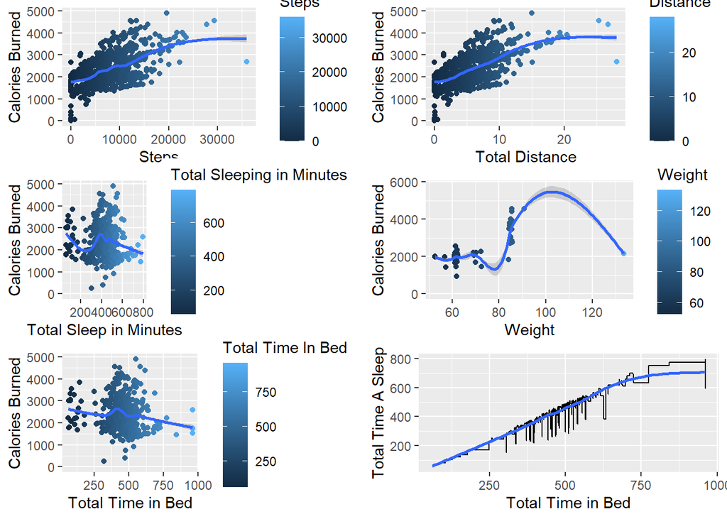

```r
# Understanding Affected Parameters to Burning Calories

Tsteps <- ggplot(finaltable, aes(x=TotalSteps, y=Calories)) + geom_point(aes(color=TotalSteps)) + geom_smooth() + labs(x="Steps", y="Calories Burned",color="Steps")
TDistance <- ggplot(finaltable, aes(x=TotalDistance, y=Calories)) + geom_point(aes(color=TotalDistance)) + geom_smooth() + labs(x="Total Distance", y="Calories Burned",color="Distance")
TMS <- ggplot(finaltable, aes(x=TotalMinutesAsleep, y=Calories)) + geom_point(aes(color=TotalMinutesAsleep)) + geom_smooth() + labs(x="Total Sleep in Minutes", y="Calories Burned",color="Total Sleeping in Minutes")
TTB <- ggplot(finaltable, aes(x=TotalTimeInBed, y=Calories)) + geom_point(aes(color=TotalTimeInBed)) + geom_smooth() + labs(x="Total Time in Bed", y="Calories Burned",color="Total Time In Bed")
WC <- ggplot(finaltable, aes(x=WeightKg, y=Calories)) + geom_point(aes(color=WeightKg)) + geom_smooth() + labs(x="Weight", y="Calories Burned",color="Weight")
TTZ <- ggplot(finaltable, aes(x=TotalTimeInBed, y=TotalMinutesAsleep)) + geom_step(direction="hv") + geom_smooth() + labs(x="Total Time in Bed", y="Total Time A Sleep",color="Difference Between Sleep and Spended time in Bed")
grid.arrange(Tsteps,TDistance,TMS,WC,TTB,TTZ)
```

# 6. Act Phase.

### Upon further investigation needed for more detailed and deceision making,

### Though from previous analysis we understanding how important to monitor multiple parameters.

### For efficient calorie burning and to relate the following studies to provide how important, for health is calorie management and monitoring for maxmize health benefits.

#### A book to further investigate health concerns and how calorie management can eliminate Risk of Chronic and diseases.

[Eat for Life: The Food and Nutrition Board’s Guide to Reducing Your Risk of Chronic Disease. by American NIH](https://www.ncbi.nlm.nih.gov/books/NBK235013/)

#### An NIH Research Article matters how important for organize and benefits of calorie management.

[Calorie restriction, immune function, and health span](https://www.nih.gov/news-events/nih-research-matters/calorie-restriction-immune-function-health-span)